# Tarea: simulación de modelos

Daniel Camarena

Los datos beauty consisten en evaluaciones de estudiantes a profesores, los estudiantes calificaron belleza y calidad de enseñanza para distintos cursos en la Universidad de Texas. Las evaluaciones de curso se realizaron al final del semestre y tiempo después 6 estudiantes que no llevaron el curso realizaron los juicios de belleza. Ajusta un modelo de regresión lineal usando las variables *edad* (age), *belleza* (btystdave), *sexo* (female) e *inglés no es primera lengua* (nonenglish) para predecir las evaluaciones del curso (courseevaluation) .

```r
library(tidyverse)
beauty <- read.csv("./data/beauty.csv")
fit_score <- lm(courseevaluation ~ age + btystdave + female + nonenglish,
                data = beauty)
```

1. La instructora A es una mujer de 50 años, el inglés es su primera lengua y tiene un puntaje de belleza de -1. El instructor B es un hombre de 60 años, su primera lengua es el inglés y tiene un puntaje de belleza de -0.5. Simula 1000 generaciones de la evaluación del curso de estos dos instructores. En tus simulaciones debes incorporar la incertidumbre en los parámetros y en la predicción.

Para hacer las simulaciones necesitarás la distribución del vector de coeficientes $\beta$, este es normal con media:

```r
coef(fit_score)
```

```
##  (Intercept)          age    btystdave       female   nonenglish
##  4.244464824 -0.002585912  0.141031893 -0.210304324 -0.332233708
```

y matriz de varianzas y covarianzas $\sigma^2 V$, donde $V$ es:

```r
summary(fit_score)$cov.unscaled
```

```
##              (Intercept)           age     btystdave        female
## (Intercept)  0.070758980 -1.331151e-03 -3.787757e-03 -1.049379e-02
## age         -0.001331151  2.653270e-05  8.781697e-05  1.324028e-04
## btystdave   -0.003787757  8.781697e-05  3.826989e-03 -2.709254e-04
## female      -0.010493789  1.324028e-04 -2.709254e-04  9.662597e-03
## nonenglish  -0.002199634 -1.791673e-06 -1.206447e-04 -5.576679e-05
##                nonenglish
## (Intercept) -2.199634e-03
## age         -1.791673e-06
## btystdave   -1.206447e-04
## female      -5.576679e-05
## nonenglish   3.801753e-02
```

y $\sigma$ se calcula como $\sigma=\hat{\sigma}\sqrt{(df)/X}$, donde X es una generación de una distribución $\chi ^2$ con $df$ (458) grados de libertad $\hat{\sigma}$ es:

```r
summary(fit_score)$sigma
```

```
## [1] 0.5320521
```

y $df$ (los grados de libertad) se obtienen:

```r
summary(fit_score)$df[2]
```

```
## [1] 458
```

```r
simula_parametros<-function(){
  #empezamos con sigma
  sigma <- 0.5320521*sqrt(458/rchisq(1, 458))
  #usamos sigma para simular las betas
  beta <- MASS::mvrnorm(1, mu = c(4.244464824,-0.002585912,0.141031893,-0.210304324,-0.332233708),
        Sigma = sigma ^ 2 * matrix(c(0.0200304151,-3.768216e-04,-1.072236e-03,-2.970576e-03,-6.226712e-04,
                                     -0.0003768216,7.510864e-06,2.485918e-05,3.748053e-05,-5.071858e-07,
                                     -0.0010722364,2.485918e-05,1.083342e-03,-7.669343e-05,-3.415205e-05,
                                     -0.0029705762,3.748053e-05,-7.669343e-05,2.735283e-03,-1.578643e-05,
                                     -0.0006226712,-5.071858e-07,-3.415205e-05,-1.578643e-05,1.076198e-02), nrow = 5))
  list(sigma = sigma, beta = beta)
}

sims_parametros <- rerun(2000, simula_parametros())
```

Una vez que obtengas una simulación del vector $\beta$ generas simulaciones para los profesores usando el modelo de regresión lineal y las simulaciones de los parámetros.

```r
#Sujeto A variables: X1 = 50, X2 = -1, X3 = 1, X4 = 0
#Sujeto B variables: X1 = 60, X2 = -0.5, X3 = 0, X4 = 0
simula_puntajes_a <- function(beta, sigma){
    Xa <- c(50,-1,1,0)
    vector_mu <- c(beta[1]+beta[2]*Xa[1]+beta[3]*Xa[2]+beta[4]*Xa[3]+beta[5]*Xa[4]) # beta_0 + beta_1 X
    obs = rnorm(1000, vector_mu, sigma)
}

sims_puntajes_a <- map(sims_parametros, ~simula_puntajes_a(beta = .[["beta"]], sigma = .[["sigma"]]))
medias_incert_a <- sims_puntajes_a %>% map_dbl(mean)

quantile(medias_incert_a, c(0.025, 0.975))
```

```
##     2.5%    97.5%
## 3.703706 3.829107
```

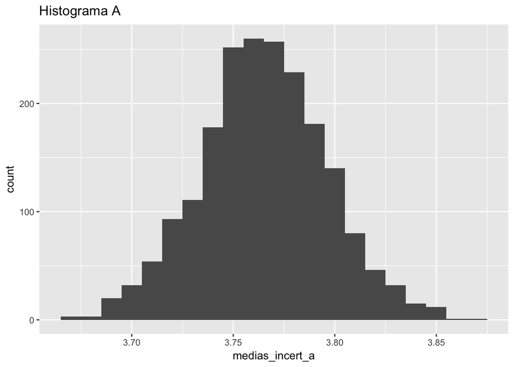

```r
qplot(medias_incert_a, geom = "histogram", binwidth = .01, main = "Histograma A")
```

```r
simula_puntajes_b <- function(beta, sigma){
    Xb <- c(60,-0.5,0,0)
    vector_mu <- c(beta[1]+beta[2]*Xb[1]+beta[3]*Xb[2]+beta[4]*Xb[3]+beta[5]*Xb[4]) # beta_0 + beta_1 X
    obs = rnorm(1000, vector_mu, sigma)
}

sims_puntajes_b <- map(sims_parametros, ~simula_puntajes_b(beta = .[["beta"]], sigma = .[["sigma"]]))
medias_incert_b <- sims_puntajes_b %>% map_dbl(mean)

quantile(medias_incert_b, c(0.025, 0.975))
```

```
##     2.5%    97.5%
## 3.965128 4.074317
```

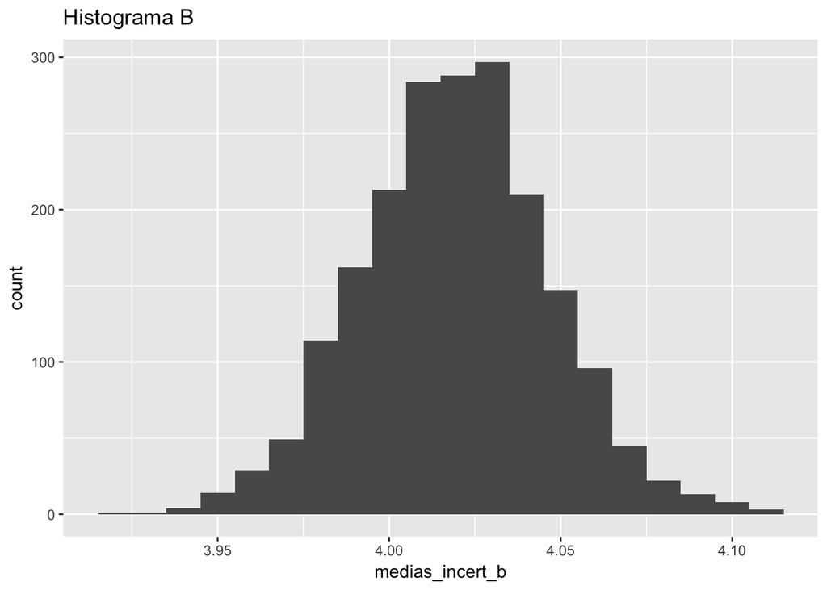

```r
qplot(medias_incert_b, geom = "histogram", binwidth = .01, main = "Histograma B")
```

- Realiza un histograma de la diferencia entre la evaluación del curso para A y B.

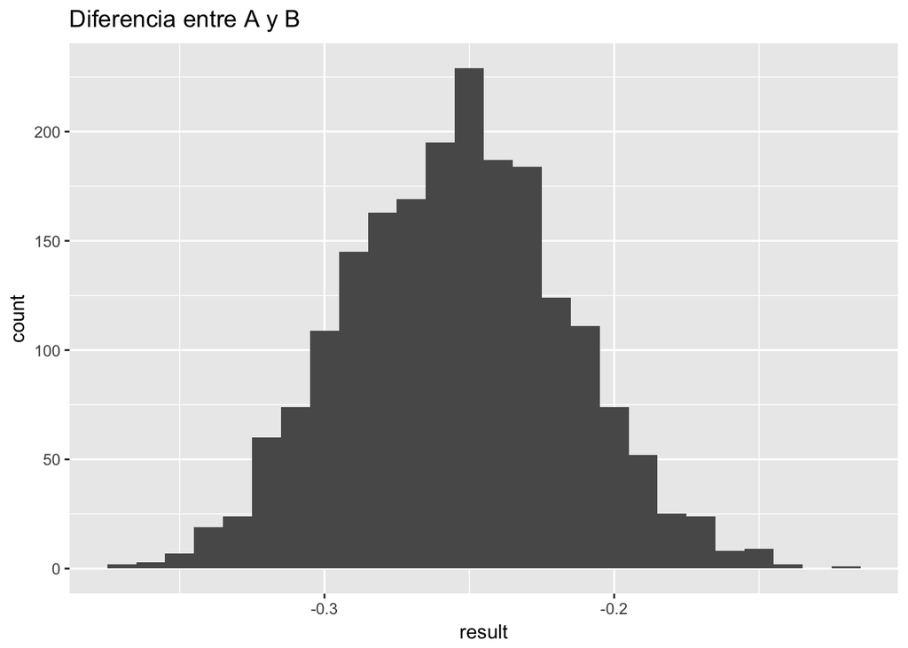

```r
result <- medias_incert_a - medias_incert_b
qplot(result, geom = "histogram", binwidth = .01, main = "Diferencia entre A y B")
```

+ ¿Cuál es la probabilidad de que A obtenga una calificación mayor?

```r
probA <- length(result[which(result>0)])/1000
print(paste("La probabilidad de que A obtenga una calificacion mayor es", probA))
```

```
## [1] "La probabilidad de que A obtenga una calificacion mayor es 0"
```

2. En el inciso anterior obtienes simulaciones de la distribución conjunta $p(\tilde{y},\beta,\sigma^2)$ donde $\beta$ es el vector de coeficientes de la regresión lineal. Para este ejercicio nos vamos a enfocar en el coeficiente de belleza ($\beta_3$), realiza 6000 simulaciones del modelo (como en el inciso anterior) y guarda las realizaciones de $\beta_3$.

```r
sims_parametros <- rerun(6000, simula_parametros())
betas<-unlist(sims_parametros)
beta_3 <- betas[which(names(betas)=="beta3")]
```

- Genera un histograma con las simulaciones de $\beta_3$.

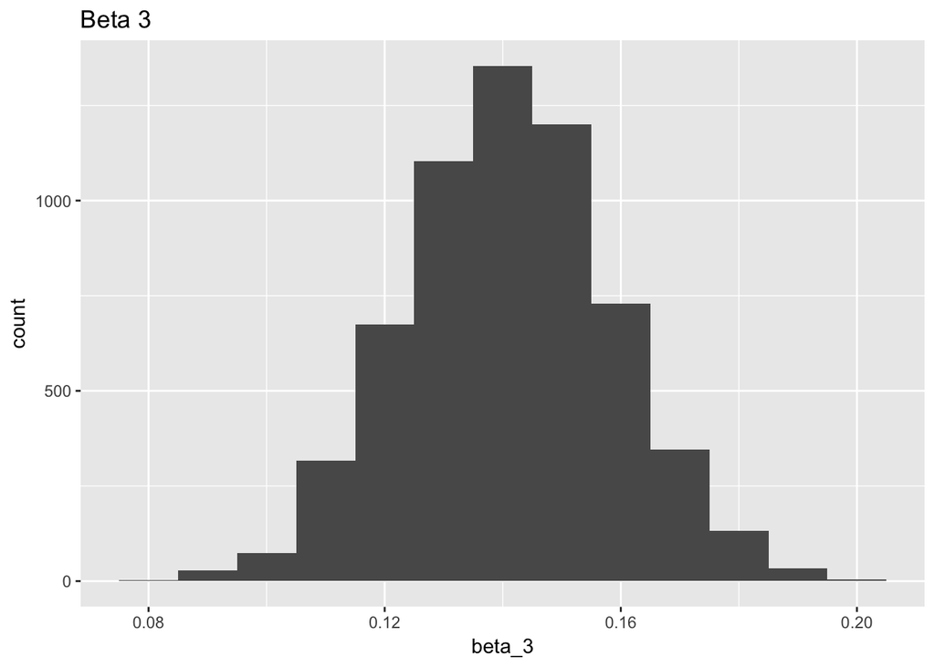

```r
qplot(beta_3, geom = "histogram", binwidth = .01, main = "Beta 3")
```

+ Calcula la media y desviación estándar de las simulaciones y comparalas con la estimación y desviación estándar del coeficiente obtenidas usando summary.

```r
paste("Media Simulacion:",mean(beta_3),"Coeficiente:",coef(fit_score)[3])
```

```
## [1] "Media Simulacion: 0.140934066029788 Coeficiente: 0.14103189312555"
```

```r
sd(beta_3)
```

```
## [1] 0.01746424
```